# Basic Probability and Stats

2018-09-03

```r
install.load::install_load('ggplot2', 'reticulate')
```

## t-test

### When to use:

When you want to know if the statistic you’ve calculated is significantly different from the population.

Assumptions of a t-test:

1. Both groups are independent of each other
2. Each observation is independent of each other
3. $\bar{x}$ follows a normal distribution with mean $\mu$ and variance $\sigma$
4. Both groups have the same variance
5. $n$ is sufficiently large. (Someone said that 30 is the magic number, but that’s completely relative.)

$$t = \frac{\bar{x}-\mu}{\sigma/\sqrt{n}}$$

$\bar{x}$ is the sample mean. You collect a sample of size $n$.

### Hypothesis:

The [null and alternative hypothesis](https://libguides.library.kent.edu/SPSS/OneSampletTest):

- $H_o$: $\bar{x} = \mu$
- $H_{a_1}$: $\bar{x} \ne \mu$ (two-sided t-test)
- $H_{a_2}$: $\bar{x} \gt \mu$ (one-sided t-test, right)
- $H_{a_3}$: $\bar{x} \lt \mu$ (one-sided t-test, left)

Doing a two-sided t-test means you’ll be checking if $\bar{x}$ is greater than or less than a value. You don’t know which. The blue area is the ‘rejection’ region. So you first get your $\bar{x}$ and your $n$ from your data. Then get your $t$-value. Then you see where your $t$-value lies on the domain.

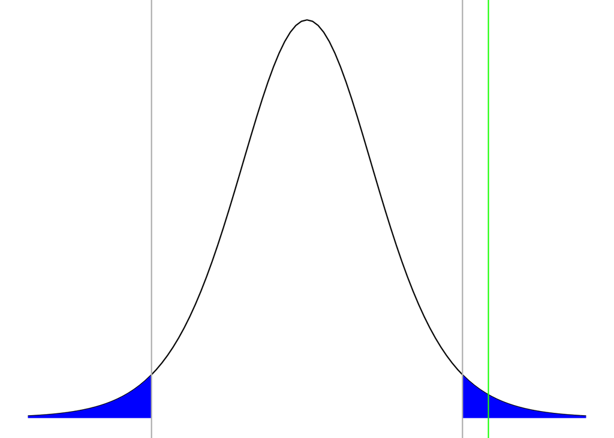

```r
x <- seq(-4, 4, length.out = 1000 )
df = 10
dat <- data.frame(x = x, y = dt(x, df=df))

obs_t_value = 2.6

ggplot(dat, aes(x=x)) +
  stat_function(fun=dt, args=list(df=df)) +
  geom_area(data=dat[dat$x > qt(.975, df=df),], aes(x=x, y=y), fill='blue') +
  geom_vline(xintercept=qt(.975, df=df), color='grey') +
  geom_vline(xintercept=obs_t_value, color='green') +
  geom_area(data=dat[dat$x < qt(.025, df=df),], aes(x=x, y=y), fill='blue') +
  geom_vline(xintercept=qt(.025, df=df), color='grey') +
  theme_void()
```

So we got a t-value that’s in the shaded area. Hooray. We ‘reject’ the null hypothesis.

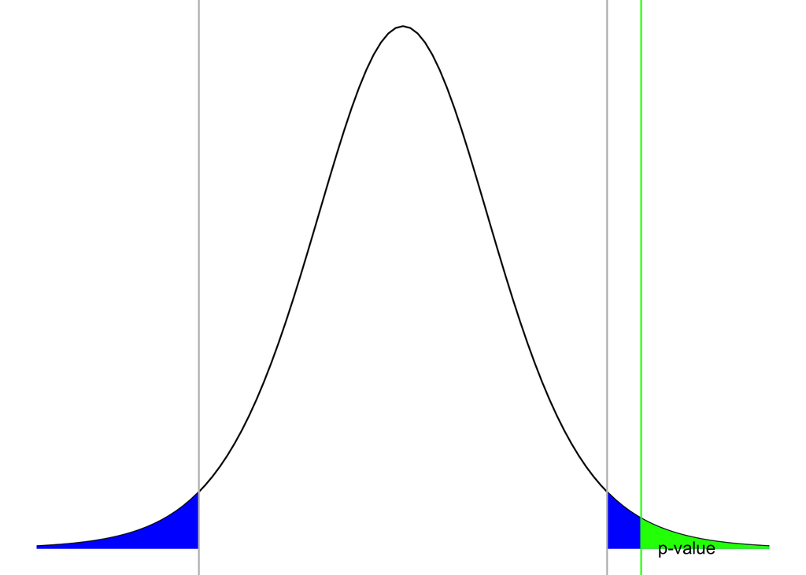

```r
ggplot(dat, aes(x=x)) +
  stat_function(fun=dt, args=list(df=df)) +
  geom_area(data=dat[dat$x > qt(.975, df=df),], aes(x=x, y=y), fill='blue') +
  geom_vline(xintercept=qt(.975, df=df), color='grey') +
  geom_vline(xintercept=obs_t_value, color='green') +
  geom_area(data=dat[dat$x > obs_t_value,], aes(x=x, y=y), fill='green') +
  annotate(geom='text', label='p-value', x = obs_t_value + .5, y=.001) +
  geom_area(data=dat[dat$x < qt(.025, df=df),], aes(x=x, y=y), fill='blue') +
  geom_vline(xintercept=qt(.025, df=df), color='grey') +
  theme_void()
```

*INTERPRETATION OF A P-VALUE:*

> The probability of getting a test statistic as extreme or more extreme than the one you observed.

Literally, the p-value is just the amount of the area to the right of your test statistic. Nothing more. It’s not the probability you reject the null hypothesis. It’s not the probability you’ll win the lottery. It’s literally just this: you got some value for $t$, called $t_{obs}$. Assuming *some* distribution for $t$, how much of the curve is shaded beyond $t_{obs}$? When doing a *hypothesis* test, you assume some *hypothesis* about $\bar{x}$.

When doing a one-sided t-test, you’ll put the alpha all in one tail. That makes it easier to reject the null hypothesis when you find an extreme value. Since it’s easier, people are pobably going to wonder why you chose to do a one-sided t-test in the first place. Here’s a one-sided test to the right.

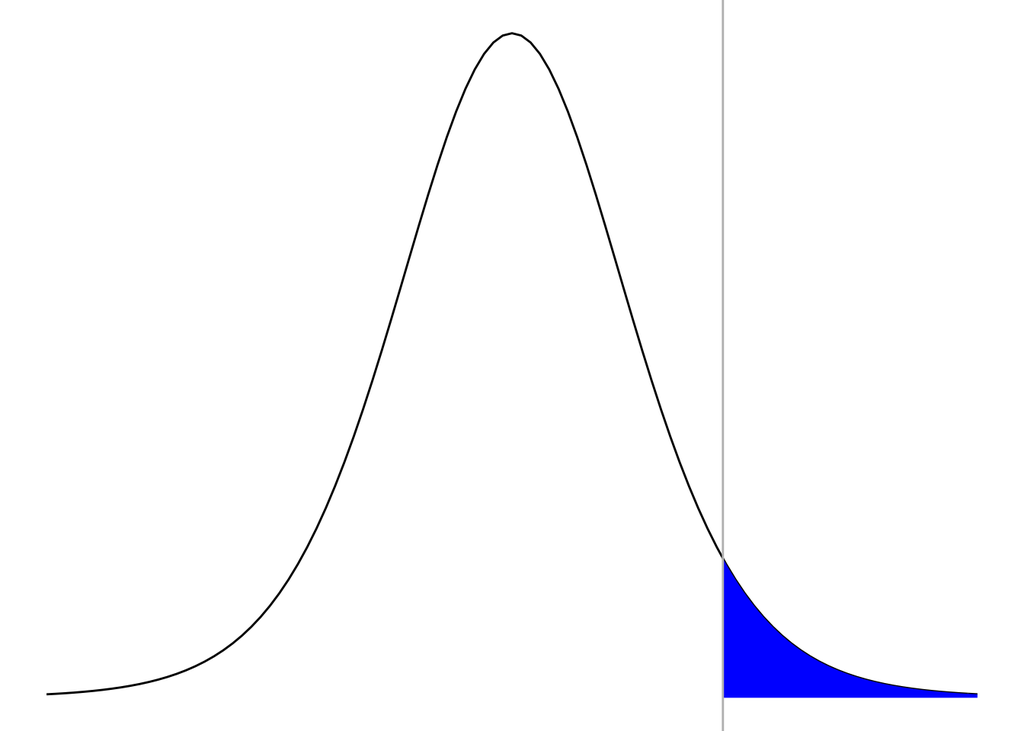

```r
ggplot(dat, aes(x=x)) +
  stat_function(fun=dt, args=list(df=df)) +
  geom_area(data=dat[dat$x > qt(.95, df=df),], aes(x=x, y=y), fill='blue') +
  geom_vline(xintercept=qt(.95, df=df), color='grey') +
  theme_void()
```

The blue area is literally 5% of the curve in all three instances. So if you get a test-statistic that falls in that area, you’ll reject the hypothesis. But don’t cheat: if you did a one-sided test to the right, but got a test-statistic wayyyy to the left, you can’t just flip the axis and then reject. That’s called [p-hacking](https://projects.fivethirtyeight.com/p-hacking/). If all you’re doing is searching for a p-value, you can always find one. More kudos to you if you get your results published and [widely disseminated via new channels](http://www.slate.com/articles/health_and_science/science/2016/01/amy_cuddy_s_power_pose_research_is_the_latest_example_of_scientific_overreach.html).

## T-test of two groups (two-sample t-test)

When you want to test if the means of two populations are different.

$$t = \frac{\bar{x_1} - \bar{x_2}}{s_p\sqrt{2/n}}$$
where
$$s_p = \sqrt{\frac{s^2_1 + s^2_2}{2}}$$
Assumptions:

- This test requires that both groups have the same sample size.
- Two populations have the same population variance.

Variants on the two-sample t-test:

### Equal sample sizes, equal population variance.

```r
t.test(x = sleep$extra[sleep$group == 2],
       y = sleep$extra[sleep$group == 1],
       var.equal = TRUE)
```

```
##
##  Two Sample t-test
##
## data:  sleep$extra[sleep$group == 2] and sleep$extra[sleep$group == 1]
## t = 1.8608, df = 18, p-value = 0.07919
## alternative hypothesis: true difference in means is not equal to 0
## 95 percent confidence interval:
##  -0.203874  3.363874
## sample estimates:
## mean of x mean of y
##      2.33      0.75
```

### Possibly Unequal sample sizes, unequal population variance (Welch t-test).

```r
grp1 = sleep$extra[sleep$group == 1]
grp2 = sleep$extra[sleep$group == 2]
t.test(x = grp2,
       y = grp1,
       var.equal = FALSE)
```

```
##
##  Welch Two Sample t-test
##
## data:  grp2 and grp1
## t = 1.8608, df = 17.776, p-value = 0.07939
## alternative hypothesis: true difference in means is not equal to 0
## 95 percent confidence interval:
##  -0.2054832  3.3654832
## sample estimates:
## mean of x mean of y
##      2.33      0.75
```

TODO: * What are the dfs?

## Simple linear regression

Assumptions [1](http://r-statistics.co/Assumptions-of-Linear-Regression.html) [2](http://people.duke.edu/~rnau/testing.htm):

- Linearity and additivity of the relationship between Y and X
- Statistical independence of the errors (no autocorrelation)
- Homoscedasticity (equal/constant variance)
- Normality of the error distribution

$$\epsilon \sim{iid} N(0, \sigma^2)$$

Hypothesis for $\beta_{intercept}$:

- $H_o$: $\beta_{intercept} \ne 0$.

Hypothesis for $\beta_{grp2}$:

- $H_o$: $\beta_{grp2} = 0$, or there is no significant difference between `grp1` and `grp2`.
- $H_a$: $\beta_{grp2} \ne 0$, or there is a signficant difference between `grp1` and `grp2`.

```r
summary(lm(extra ~ group, data = sleep))
```

```
##
## Call:
## lm(formula = extra ~ group, data = sleep)
##
## Residuals:
##    Min     1Q Median     3Q    Max
## -2.430 -1.305 -0.580  1.455  3.170
##
## Coefficients:
##             Estimate Std. Error t value Pr(>|t|)
## (Intercept)   0.7500     0.6004   1.249   0.2276
## group2        1.5800     0.8491   1.861   0.0792 .
## ---
## Signif. codes:  0 '***' 0.001 '**' 0.01 '*' 0.05 '.' 0.1 ' ' 1
##
## Residual standard error: 1.899 on 18 degrees of freedom
## Multiple R-squared:  0.1613, Adjusted R-squared:  0.1147
## F-statistic: 3.463 on 1 and 18 DF,  p-value: 0.07919
```

What have we learned:

- The coefficient of a factor level plus the intercept is the actual mean for that factor level.
- The $t$-value of a coefficient corresponds to the $t$-test of whether the two groups are the same.

```python
a = 10
a += 2
```

## Mann-Whitney U-test

[Wiki](https://en.wikipedia.org/wiki/Mann%E2%80%93Whitney_U_test).

- Doesn’t require the assumption that $\bar{x}$ follows a normal distribution.
- Non-parametric test

How it works:

- $H_o$: Both populations follow the same distribution.
- $H_a$: The distributions are not equal

```r
# wilcox.test()
```

## Wilcoxon test

## t-test of proportions

## Power test

## t-test for binomial data

## Regression for binomial data